# final

Cy

12/9/2020

#Task III - Devise five questions on a five point Likert scale that ask members of your group about their experience with your chosen task - Collect data from all members of your group - Run a PCA analysis on the data - What does PC1 represent in your analysis? - Visualize the PC1 results for each member of your group #Libraries

```r
library(ggplot2)
library(GGally)
library(factoextra)
library(dplyr)
```

#Data import

```r
S1 = read.csv("surveydata.csv", header = T)
```

#Visualize correlations

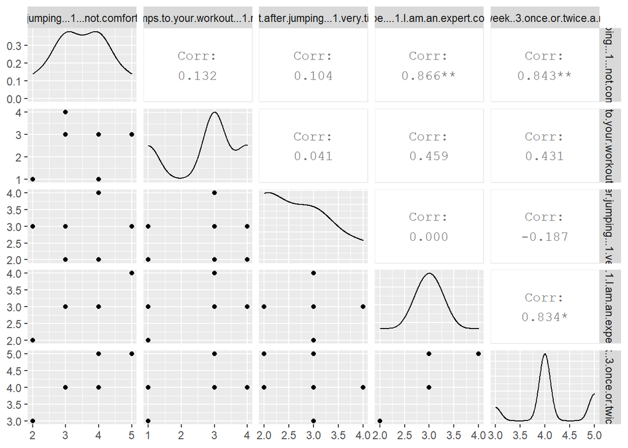

```r
ggpairs(S1, 2:6, progress = FALSE)
```

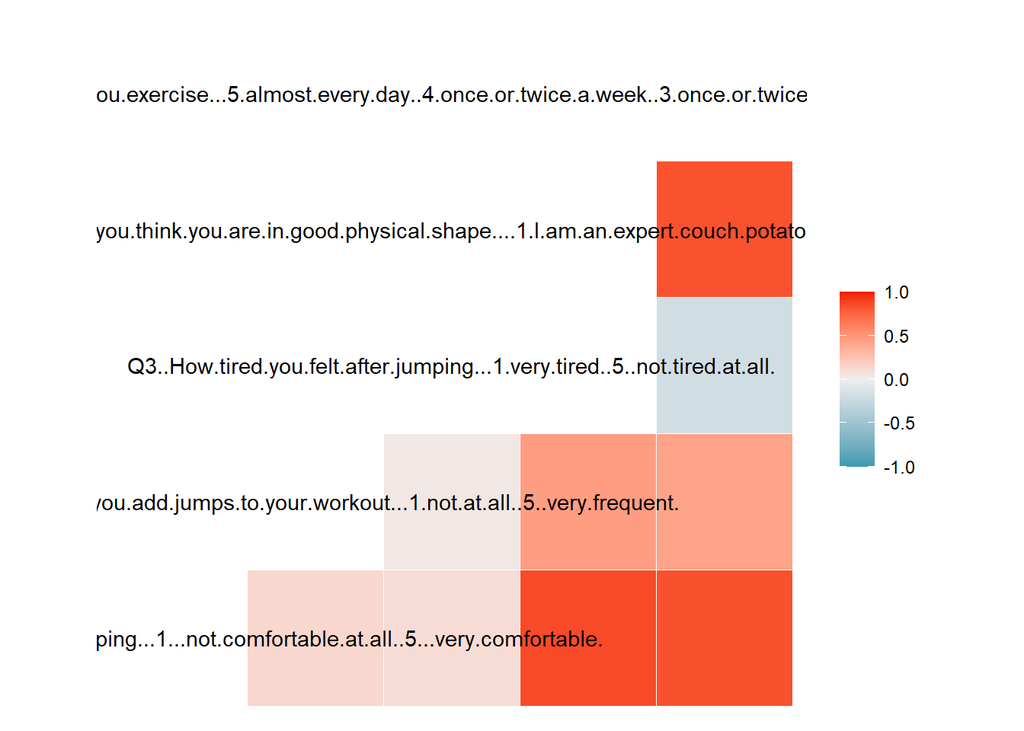

```r
ggcorr(S1[,-1], method = c("everything", "pearson"))
```

#PCA

```r
drop <- c("Name")
S2 <- S1[,!(names(S1) %in% drop)]
pcas <- prcomp(S2, scale. = TRUE)

pcas$sdev
```

```
## [1] 1.6978677 1.0242125 0.9459755 0.3816359 0.1664893
```

```r
#To convert this into variance accounted for we can square it, these numbers are proportional to the eigenvalue

pcas$sdev^2
```

```
## [1] 2.88275458 1.04901118 0.89486962 0.14564594 0.02771869
```

```r
#A summary of our pca will give us the proportion of variance accounted for by each component

summary(pcas)
```

```
## Importance of components:
##                           PC1    PC2    PC3     PC4     PC5
## Standard deviation     1.6979 1.0242 0.9460 0.38164 0.16649
## Proportion of Variance 0.5766 0.2098 0.1790 0.02913 0.00554
## Cumulative Proportion  0.5766 0.7863 0.9653 0.99446 1.00000
```

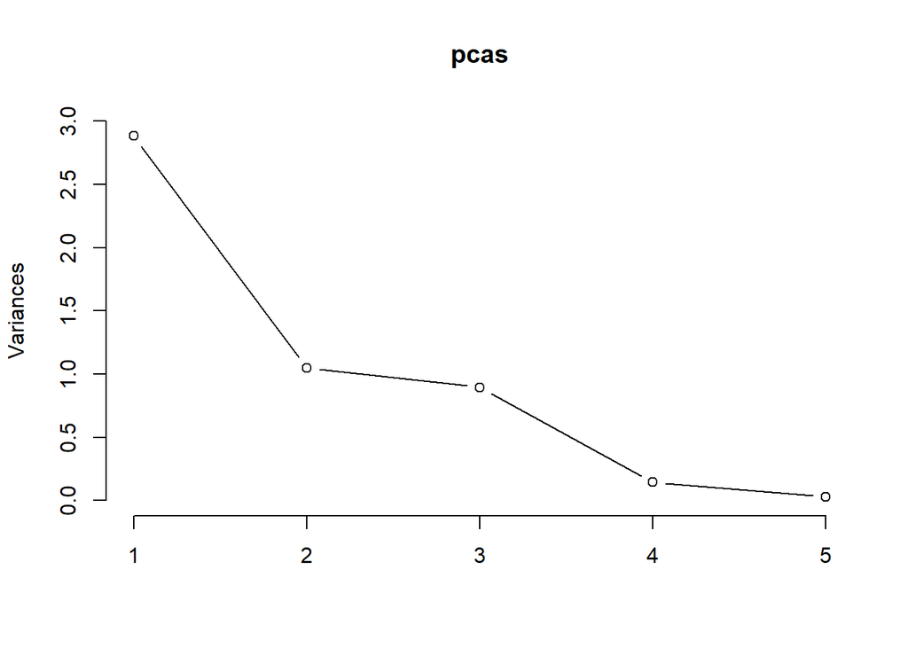

```r
#We can look at this to get an idea of which components we should keep and which we should drop

plot(pcas, type = "lines",ylim=c(0,3))
```

```r
pcas$rotation
```

```
##                                                                                                                                                                                 PC1
## Q1..How.comfortable.your.feel.jumping...1...not.comfortable.at.all..5...very.comfortable.                                                                                0.52902674
## Q2.How.often.you.add.jumps.to.your.workout...1.not.at.all..5..very.frequent.                                                                                             0.30168028
## Q3..How.tired.you.felt.after.jumping...1.very.tired..5..not.tired.at.all.                                                                                               -0.01970875
## Q4..Do.you.think.you.are.in.good.physical.shape....1.I.am.an.expert.couch.potato...5..I.can.run.a.marathon.tomorrow.                                                     0.56383739
## Q5..How.often.do.you.exercise...5.almost.every.day..4.once.or.twice.a.week..3.once.or.twice.a.month..2.once.or.twice.three.months..1.once.or.twice.half.a.year.or.less.  0.55751114
##                                                                                                                                                                                 PC2
## Q1..How.comfortable.your.feel.jumping...1...not.comfortable.at.all..5...very.comfortable.                                                                               -0.12478839
## Q2.How.often.you.add.jumps.to.your.workout...1.not.at.all..5..very.frequent.                                                                                            -0.07626097
## Q3..How.tired.you.felt.after.jumping...1.very.tired..5..not.tired.at.all.                                                                                               -0.97374913
## Q4..Do.you.think.you.are.in.good.physical.shape....1.I.am.an.expert.couch.potato...5..I.can.run.a.marathon.tomorrow.                                                    -0.04323691
## Q5..How.often.do.you.exercise...5.almost.every.day..4.once.or.twice.a.week..3.once.or.twice.a.month..2.once.or.twice.three.months..1.once.or.twice.half.a.year.or.less.  0.16898323
##                                                                                                                                                                                 PC3
## Q1..How.comfortable.your.feel.jumping...1...not.comfortable.at.all..5...very.comfortable.                                                                                0.42562630
## Q2.How.often.you.add.jumps.to.your.workout...1.not.at.all..5..very.frequent.                                                                                            -0.90253721
## Q3..How.tired.you.felt.after.jumping...1.very.tired..5..not.tired.at.all.                                                                                                0.02330487
## Q4..Do.you.think.you.are.in.good.physical.shape....1.I.am.an.expert.couch.potato...5..I.can.run.a.marathon.tomorrow.                                                     0.03474602
## Q5..How.often.do.you.exercise...5.almost.every.day..4.once.or.twice.a.week..3.once.or.twice.a.month..2.once.or.twice.three.months..1.once.or.twice.half.a.year.or.less.  0.05018408
##                                                                                                                                                                                 PC4
## Q1..How.comfortable.your.feel.jumping...1...not.comfortable.at.all..5...very.comfortable.                                                                                0.04600794
## Q2.How.often.you.add.jumps.to.your.workout...1.not.at.all..5..very.frequent.                                                                                             0.03494557
## Q3..How.tired.you.felt.after.jumping...1.very.tired..5..not.tired.at.all.                                                                                                0.14040372
## Q4..Do.you.think.you.are.in.good.physical.shape....1.I.am.an.expert.couch.potato...5..I.can.run.a.marathon.tomorrow.                                                    -0.72317167
## Q5..How.often.do.you.exercise...5.almost.every.day..4.once.or.twice.a.week..3.once.or.twice.a.month..2.once.or.twice.three.months..1.once.or.twice.half.a.year.or.less.  0.67377415
##                                                                                                                                                                                PC5
## Q1..How.comfortable.your.feel.jumping...1...not.comfortable.at.all..5...very.comfortable.                                                                               -0.7220001
## Q2.How.often.you.add.jumps.to.your.workout...1.not.at.all..5..very.frequent.                                                                                            -0.2955988
## Q3..How.tired.you.felt.after.jumping...1.very.tired..5..not.tired.at.all.                                                                                                0.1765443
## Q4..Do.you.think.you.are.in.good.physical.shape....1.I.am.an.expert.couch.potato...5..I.can.run.a.marathon.tomorrow.                                                     0.3950106
## Q5..How.often.do.you.exercise...5.almost.every.day..4.once.or.twice.a.week..3.once.or.twice.a.month..2.once.or.twice.three.months..1.once.or.twice.half.a.year.or.less.  0.4518141
```

```r
loadings <- abs(pcas$rotation) #abs() will make all eigenvectors positive

head(summary(pcas))
```

[output not shown]

[output cut: 49 more lines]

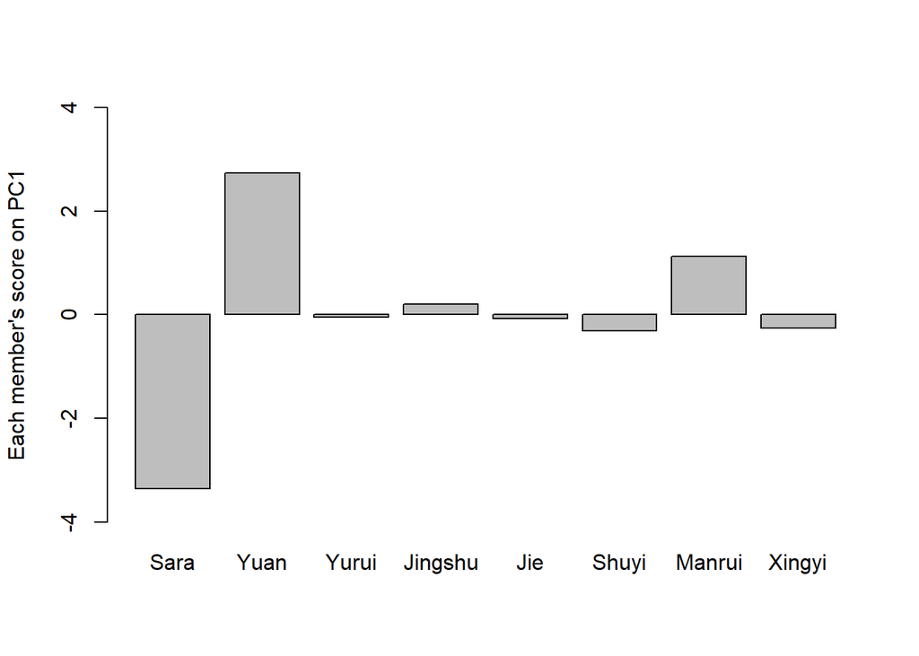

```r
V1 = pcas$x
V2 <- V1
rownames(V2)<-S1$Name
V3 <- as.data.frame(V2)
names <- c("Sara","Yuan","Yurui","Jingshu","Jie","Shuyi","Manrui","Xingyi")
barplot(V3$PC1, ylab = "Each member's score on PC1", ylim=c(-4,4), names.arg=names, cex.names=1)
```

#What PC1 represents